# Incidência e mortalidade por linfoma de Hodgkin em crianças e adolescentes

Laboratório de Estatística - Ivan Robert Enriquez Guzman

Elias Ribeiro Rosa Junior e Ornella Scardua Ferreira

### Introdução

Linfoma é um câncer do sangue que se origina no sistema linfático, o qual é composto por linfonodos (gânglios) e tecidos que produzem células responsáveis em defender o organismo humano de infeções e outros tumores. Existem dois tipos de linfoma, e a diferença entre eles se dá pelas características encontradas no tumor. Enquanto no linfoma de Hodgkin as células malignas são grandes e, portanto, fáceis de identificá-las nos linfonodos doentes (as células de Reed-Sternberg), no linfoma não-Hodgkin não há padrão celular.

Em particular, o linfoma (ou doença) de Hodgkin surge quando um linfócito se transforma em uma célula maligna capaz de se multiplicar descontroladamente e de se disseminar de um linfonodo para outro por meio dos vasos linfáticos. Se não tratadas precocemente, os tumores podem se espalhar para tecidos próximos ou mesmo para outros órgãos do corpo. Além disso, uma pessoa acometida pela doença de Hodgkin, geralmente, apresenta ínguas superficiais e indolores no pescoço, axilas e virilha e pode manifestar febre, fadiga, sudorese noturna, perda de peso repentina e coceira na pele. Quando os linfonodos são atacados na região do tórax, os sintomas são dor torácica, tosse e falta de ar; na pelve e no abdômen, os sintomas são sensação de estômago cheio e distensão abdominal.

Segundo o Instituto Nacional de Câncer (INCA), o linfoma de Hodgkin é mais incidente entre homens adolescentes e adultos (15 a 39 anos) e idosos (75 anos ou mais) do que entre mulheres com as mesmas faixas de idade, e os fatores de risco estão relacionados ao uso de drogas imunossupressoras, infecção pelo HIV, deficiência imunológica e, ainda que incomum, histórico familiar da doença. No entanto, em crianças e adolescentes de até 19 anos (STELIAROVA-FOUCHER, Eva et al., 2004), as causas ainda são desconhecidas e pouco exploradas, embora estudos já tenham apontado para a predisposição genética e exposição ambiental (STILLER, 2007). Por outra perspectiva, estudos também mostraram que as taxas de incidência de cânceres infantojuvenis estão aumentando no decorrer dos anos em todas as faixas etárias dessa população, sem contar que cerca de 80% dos casos ocorreram em países com baixo índice de desenvolvimento humano (IDH) e serviços de saúde precários (FERLAY, Jacques et al., 2015).

Em razão disso, este estudo tem como objetivo analisar a incidência e principalmente a mortalidade por linfoma de Hodgkin em crianças e adolescentes de até 19 anos no Brasil, por faixa etária e região, indicando os potenciais fatores de risco e calculando as estimativas das taxas de mortalidade por essa doença para os próximos anos. Os dados a serem considerados são do Sistema de Informação sobre Mortalidade (SIM), disponibilizados no aplicativo TABNET, do DataSUS, pelo Ministério da Saúde.

### Análise Descritiva

Analisamos as bases de dados do Sistema de Informação sobre Mortalidade (SIM) datadas de 2000 a 2020, anos em que os dados estimados da população brasileira estavam disponíveis. A princípio, consideramos como variáveis **ano do óbito por linfoma de Hodgkin**, **macrorregião de saúde** e **faixa etária**.

Dentre os 48.426 óbitos por qualquer tipo de neoplasia que ocorreram no público infanto-juvenil, 792 foram devido ao linfoma de Hodgking, correspondendo a apenas 1,64% dos casos de cânceres. Além disso, as taxas de mortalidade não ultrapassaram 0,036 em todo o período observado nem apresentaram tendência de crescimento ou descrescimento ao longo dos anos, como pode ser visto na Figura 1. Resultados similares acontecem quando avaliamos as tendêncidas das taxas de mortalidade ao considerar as regiões brasileiras. No mapa de calor apresentado na Figura 2, apenas o Sul parece indicar redução sutil no número de óbitos pela doença ao avançar dos anos.

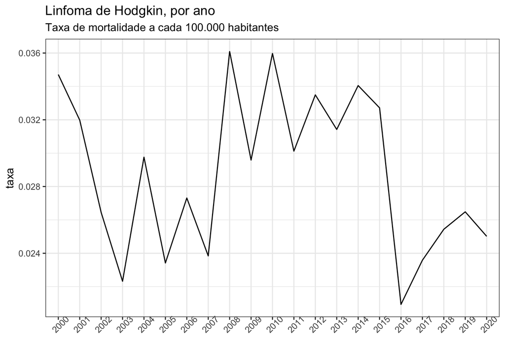

Figura 1: Taxa de mortalidade por Linfoma de Hodgkin em crianças e adolescentes no Brasil, por ano.

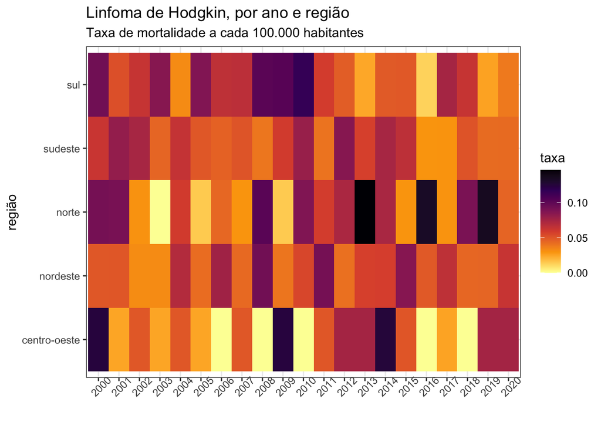

Figura 2: Taxa de mortalidade por Linfoma de Hodgkin em crianças e adolescentes no Brasil, por ano e região.

Dois aspectos muito importantes ao estudar a incidência e mortalidade por linfoma de Hodgkin em crianças e adolescentes são faixa etária, posto que jovens adultos são mais propensos à doença, e região de residência, uma vez que parâmetros socieconômicos são consideradas associações causais para o desenvolvimento de um câncer. Ao observar os mapas geográficos na Figura 3, constatamos que o linfoma foi mais letal nos indivíduos que atenderam à faixa de idade de 15 a 19 anos, conclusão na direção com o que o INCA diz a respeito dos grupos mais afetados pelo linfoma de Hodgkin. Por outro lado, um fato curioso que podemos notar nessa mesma figura são as regiões em que mais óbitos ocorreram: Norte e Sul. Sabendo que os estados do Sul configuram entre os estados com os maiores IDHs do país, é de estranhar que eles tenham uma das maiores taxas de mortalidade nessa ocasião. O que nos leva a pensar que expectativa de vida, nível de educação e renda nacional bruta per capita não influenciam positiva e negativamente para o desenvolvimento e complicações clínicas do linfoma de Hodgkin.

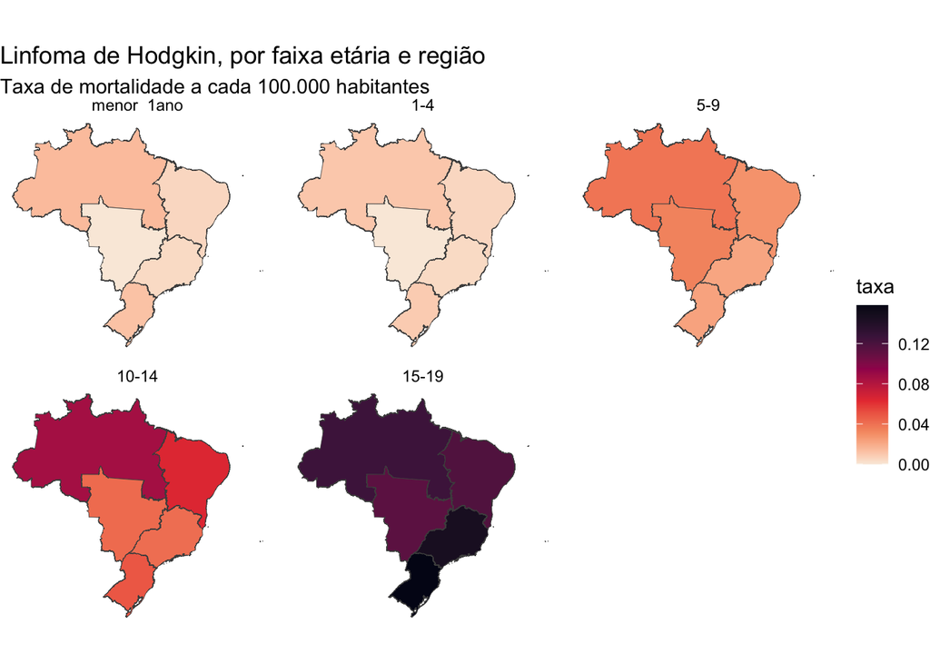

Figura 3: Taxa de mortalidade por Linfoma de Hodgkin em crianças e adolescentes no Brasil, por faixa etária e região.